## Coursera - Reproducible Research (repdata-006)

### **Peer Assessment 1**

### Loading and preprocessing the data:

```r
library(knitr)
library(markdown)
opts_chunk$set(echo = TRUE, fig.path="figures/", fig.align = "center")

df <- read.csv("/home/cesar/Coursera/A - Reproducible Research/activity.csv", header = TRUE)
```

### Calculating the mean of total number of steps taken per day:

```r
total_steps <- tapply(df$steps, df$date, sum, na.rm = TRUE)
```

- Making a histogram of the total number of steps taken each day

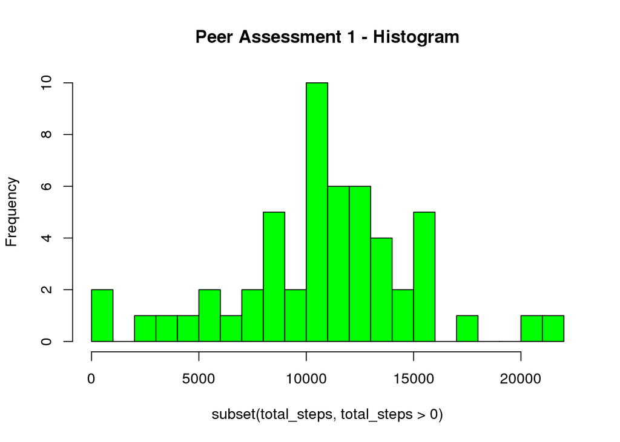

```r
hist(subset(total_steps, total_steps > 0), breaks = 20, col = "green", main = "Peer Assessment 1 - Histogram")
```

- Calculating and reporting the mean and median total number of steps taken per day

```r
mean(total_steps)
```

```
## [1] 9354
```

```r
median(total_steps )
```

```
## [1] 10395
```

### Average daily activity pattern:

- Making a time series plot

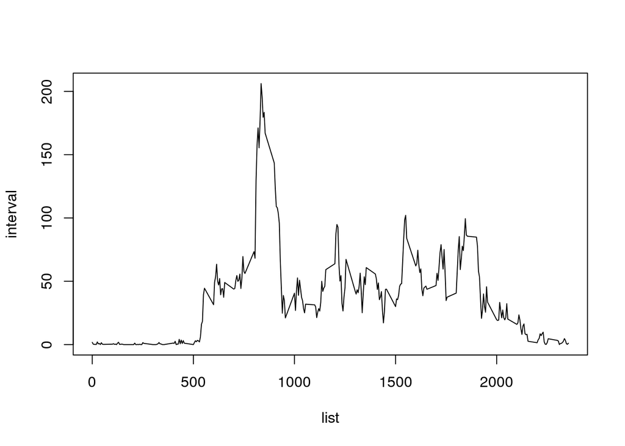

```r
interval <- tapply(df$steps, df$interval, mean, na.rm = TRUE)
list <- unique(df$interval)

plot(list, interval, type = "l")
```

- Which 5-minute interval, on average across all the days in the dataset, contains the maximum number of steps?

```r
interval <- data.frame(interval)
minutes <- interval[ interval == max(interval$interval), ]
minutes
```

```
##   835
## 206.2
```

### Imputing missing values:

- 1. Calculate and report the total number of missing values in the dataset (i.e. the total number of rows with NAs)

```r
NAs <- sum(is.na(df$steps))
NAs
```

```
## [1] 2304
```

- 2. Devise a strategy for filling in all of the missing values in the dataset. The strategy does not need to be sophisticated.

```r
mean_steps <- mean(total_steps)
```

- 3. Create a new dataset that is equal to the original dataset but with the missing data filled in.

```r
new_df <- df

for( i in 1:17568)
{
    if( is.na( new_df[ i, 1] ) == TRUE)
    {
        new_df[ i, 1] <- mean_steps
    }
}
```

```r
new_total_steps <- tapply(new_df$steps, new_df$date, sum )
# hist(subset(new_total_steps[ , 1]), breaks = 20, col = "blue", main = "New Histogram")
```